## Part A

• PROJECT OBJECTIVE  
Developing a AIML model which can predict the condition of the patient depending on the received test results

```python
import pandas as pd
import numpy as np
import matplotlib.pyplot as plt
import seaborn as sns
```

### Data Understanding

A. Read all the 3 CSV files as DataFrame and store them into 3 separate variables

```python
# Reading all data sets into variables
Normal = pd.read_csv('Part1+-+Normal.csv')
H = pd.read_csv('Part1+-+Type_H.csv')
S = pd.read_csv('Part1+-+Type_S.csv')
```

```python
# Checking values in Normal
Normal.head()
```

|  | P_incidence | P_tilt | L_angle | S_slope | P_radius | S_Degree | Class |
| --- | --- | --- | --- | --- | --- | --- | --- |
| 0 | 38.505273 | 16.964297 | 35.112814 | 21.540976 | 127.632875 | 7.986683 | Normal |
| 1 | 54.920858 | 18.968430 | 51.601455 | 35.952428 | 125.846646 | 2.001642 | Normal |
| 2 | 44.362490 | 8.945435 | 46.902096 | 35.417055 | 129.220682 | 4.994195 | Normal |
| 3 | 48.318931 | 17.452121 | 48.000000 | 30.866809 | 128.980308 | -0.910941 | Normal |
| 4 | 45.701789 | 10.659859 | 42.577846 | 35.041929 | 130.178314 | -3.388910 | Normal |

```python
# Checking values in H
H.head()
```

|  | P_incidence | P_tilt | L_angle | S_slope | P_radius | S_Degree | Class |
| --- | --- | --- | --- | --- | --- | --- | --- |
| 0 | 63.027817 | 22.552586 | 39.609117 | 40.475232 | 98.672917 | -0.254400 | Type_H |
| 1 | 39.056951 | 10.060991 | 25.015378 | 28.995960 | 114.405425 | 4.564259 | Type_H |
| 2 | 68.832021 | 22.218482 | 50.092194 | 46.613539 | 105.985135 | -3.530317 | Type_H |
| 3 | 69.297008 | 24.652878 | 44.311238 | 44.644130 | 101.868495 | 11.211523 | Type_H |
| 4 | 49.712859 | 9.652075 | 28.317406 | 40.060784 | 108.168725 | 7.918501 | Type_H |

```python
S.head()
```

|  | P_incidence | P_tilt | L_angle | S_slope | P_radius | S_Degree | Class |
| --- | --- | --- | --- | --- | --- | --- | --- |
| 0 | 74.377678 | 32.053104 | 78.772013 | 42.324573 | 143.560690 | 56.125906 | Type_S |
| 1 | 89.680567 | 32.704435 | 83.130732 | 56.976132 | 129.955476 | 92.027277 | Type_S |
| 2 | 44.529051 | 9.433234 | 52.000000 | 35.095817 | 134.711772 | 29.106575 | Type_S |
| 3 | 77.690577 | 21.380645 | 64.429442 | 56.309932 | 114.818751 | 26.931841 | Type_S |
| 4 | 76.147212 | 21.936186 | 82.961502 | 54.211027 | 123.932010 | 10.431972 | Type_S |

B. Print Shape and columns of all the 3 DataFrames. [1 Mark]

```python
print('Shape of Normal Dataset:{}'.format(Normal.shape))
print('It has total {0} rows with {1} columns'.format(Normal.shape[0],len(Normal.columns)))
print('Column Names in {Normal} Dataset:\n',(list(Normal.columns)))
```

```
Shape of Normal Dataset:(100, 7)
It has total 100 rows with 7 columns
Column Names in {Normal} Dataset:
 ['P_incidence', 'P_tilt', 'L_angle', 'S_slope', 'P_radius', 'S_Degree', 'Class']
```

```python
print('Shape of H Dataset:{}'.format(H.shape))
print('It has total {0} rows with {1} columns'.format(H.shape[0],len(H.columns)))
print('Column Names in Normal Dataset:\n',(list(H.columns)))
```

```
Shape of H Dataset:(60, 7)
It has total 60 rows with 7 columns
Column Names in Normal Dataset:
 ['P_incidence', 'P_tilt', 'L_angle', 'S_slope', 'P_radius', 'S_Degree', 'Class']
```

```python
print('Shape of S Dataset:{}'.format(S.shape))
print('It has total {0} rows with {1} columns'.format(S.shape[0],len(S.columns)))
print('Column Names in Normal Dataset:\n',(list(S.columns)))
print()
print()
```

```
Shape of S Dataset:(150, 7)
It has total 150 rows with 7 columns
Column Names in Normal Dataset:
 ['P_incidence', 'P_tilt', 'L_angle', 'S_slope', 'P_radius', 'S_Degree', 'Class']
```

C. Compare Column names of all the 3 DataFrames and clearly write observations.

All the Columns in all 3 dataframes have identical names  
We merge these columns and try to predict the classes based on 3 categories

D. Print DataTypes of all the 3 DataFrames.

```python
pd.DataFrame(Normal.dtypes,columns = ['Data_type']).reset_index().rename(columns = {'index':'column'})
```

|  | column | Data_type |
| --- | --- | --- |
| 0 | P_incidence | float64 |
| 1 | P_tilt | float64 |
| 2 | L_angle | float64 |
| 3 | S_slope | float64 |
| 4 | P_radius | float64 |
| 5 | S_Degree | float64 |
| 6 | Class | object |

```python
pd.DataFrame(H.dtypes,columns = ['Data_type']).reset_index().rename(columns = {'index':'column'})
```

|  | column | Data_type |
| --- | --- | --- |
| 0 | P_incidence | float64 |
| 1 | P_tilt | float64 |
| 2 | L_angle | float64 |
| 3 | S_slope | float64 |
| 4 | P_radius | float64 |
| 5 | S_Degree | float64 |
| 6 | Class | object |

```python
pd.DataFrame(S.dtypes,columns = ['Data_type']).reset_index().rename(columns = {'index':'column'})
```

|  | column | Data_type |
| --- | --- | --- |
| 0 | P_incidence | float64 |
| 1 | P_tilt | float64 |
| 2 | L_angle | float64 |
| 3 | S_slope | float64 |
| 4 | P_radius | float64 |
| 5 | S_Degree | float64 |
| 6 | Class | object |

E. Observe and share variation in ‘Class’ feature of all the 3 DaraFrames.

```python
Normal['Class'].value_counts()
```

```
Normal    73
Nrmal     27
Name: Class, dtype: int64
```

Class column of above dataset has garbage values.They should be treated with single value as Normal

```python
H['Class'].value_counts()
```

```
Type_H    37
type_h    23
Name: Class, dtype: int64
```

Class column of above dataset has garbage values.They should be treated with single value as Type_H

```python
S['Class'].value_counts()
```

```
Type_S    133
tp_s       17
Name: Class, dtype: int64
```

Class column of above dataset has garbage values.They should be treated with single value as Type_S

## 2. Data Preparation and Exploration:

A. Unify all the variations in ‘Class’ feature for all the 3 DataFrames

```python
Normal.head()
```

|  | P_incidence | P_tilt | L_angle | S_slope | P_radius | S_Degree | Class |
| --- | --- | --- | --- | --- | --- | --- | --- |
| 0 | 38.505273 | 16.964297 | 35.112814 | 21.540976 | 127.632875 | 7.986683 | Normal |
| 1 | 54.920858 | 18.968430 | 51.601455 | 35.952428 | 125.846646 | 2.001642 | Normal |
| 2 | 44.362490 | 8.945435 | 46.902096 | 35.417055 | 129.220682 | 4.994195 | Normal |
| 3 | 48.318931 | 17.452121 | 48.000000 | 30.866809 | 128.980308 | -0.910941 | Normal |
| 4 | 45.701789 | 10.659859 | 42.577846 | 35.041929 | 130.178314 | -3.388910 | Normal |

```python
Normal.Class.value_counts()
```

```
Normal    73
Nrmal     27
Name: Class, dtype: int64
```

```python
Normal['Class'].replace({'Nrmal':'Normal'},inplace = True)
```

```python
Normal.Class.value_counts()
```

```
Normal    100
Name: Class, dtype: int64
```

```python
H.Class.value_counts()
```

```
Type_H    37
type_h    23
Name: Class, dtype: int64
```

```python
H['Class'].replace({'type_h':'Type_H'},inplace = True)
```

```python
S['Class'].value_counts()
```

```
Type_S    133
tp_s       17
Name: Class, dtype: int64
```

```python
S['Class'].replace({'tp_s':'Type_S'},inplace = True)
```

```python
Normal.head(1)
```

|  | P_incidence | P_tilt | L_angle | S_slope | P_radius | S_Degree | Class |
| --- | --- | --- | --- | --- | --- | --- | --- |
| 0 | 38.505273 | 16.964297 | 35.112814 | 21.540976 | 127.632875 | 7.986683 | Normal |

```python
S.head(1)
```

|  | P_incidence | P_tilt | L_angle | S_slope | P_radius | S_Degree | Class |
| --- | --- | --- | --- | --- | --- | --- | --- |
| 0 | 74.377678 | 32.053104 | 78.772013 | 42.324573 | 143.56069 | 56.125906 | Type_S |

B.Combining all the 3 Dataframes to forming a single dataframe

```python
df = Normal.append(H).append(S)
```

```python
df.shape
```

```
(310, 7)
```

```python
df.tail()
```

|  | P_incidence | P_tilt | L_angle | S_slope | P_radius | S_Degree | Class |
| --- | --- | --- | --- | --- | --- | --- | --- |
| 145 | 80.111572 | 33.942432 | 85.101608 | 46.169139 | 125.593624 | 100.292107 | Type_S |
| 146 | 95.480229 | 46.550053 | 59.000000 | 48.930176 | 96.683903 | 77.283072 | Type_S |
| 147 | 74.094731 | 18.823727 | 76.032156 | 55.271004 | 128.405731 | 73.388216 | Type_S |
| 148 | 87.679087 | 20.365613 | 93.822416 | 67.313473 | 120.944829 | 76.730629 | Type_S |
| 149 | 48.259920 | 16.417462 | 36.329137 | 31.842457 | 94.882336 | 28.343799 | Type_S |

```python
df['Class'].value_counts()
```

```
Type_S    150
Normal    100
Type_H     60
Name: Class, dtype: int64
```

C. Printing 5 random samples of the data frame

```python
df.sample(5)
```

|  | P_incidence | P_tilt | L_angle | S_slope | P_radius | S_Degree | Class |
| --- | --- | --- | --- | --- | --- | --- | --- |
| 76 | 88.024499 | 39.844669 | 81.774473 | 48.179830 | 116.601538 | 56.766083 | Type_S |
| 128 | 85.680950 | 38.650035 | 82.680977 | 47.030914 | 120.840707 | 61.959034 | Type_S |
| 73 | 81.754419 | 20.123466 | 70.560440 | 61.630954 | 119.425086 | 55.506889 | Type_S |
| 28 | 44.551012 | 21.931147 | 26.785916 | 22.619865 | 111.072920 | 2.652321 | Type_H |
| 20 | 65.611802 | 23.137919 | 62.582179 | 42.473883 | 124.128001 | -4.083298 | Normal |

```python
df.info()
print()
```

```
<class 'pandas.core.frame.DataFrame'>
Int64Index: 310 entries, 0 to 149
Data columns (total 7 columns):
 #   Column       Non-Null Count  Dtype
---  ------       --------------  -----
 0   P_incidence  310 non-null    float64
 1   P_tilt       310 non-null    float64
 2   L_angle      310 non-null    float64
 3   S_slope      310 non-null    float64
 4   P_radius     310 non-null    float64
 5   S_Degree     310 non-null    float64
 6   Class        310 non-null    object
dtypes: float64(6), object(1)
memory usage: 19.4+ KB
```

Checking Null values in teh dataframe

```python
print('Feature wise Percentage of Null values ::\n',df.isna().sum()/len(df))
```

```
Feature wise Percentage of Null values ::
 P_incidence    0.0
P_tilt         0.0
L_angle        0.0
S_slope        0.0
P_radius       0.0
S_Degree       0.0
Class          0.0
dtype: float64
```

There are no null values found

E .Observing 5 point summary of the resulting combined dataframe

```python
df.describe()
```

|  | P_incidence | P_tilt | L_angle | S_slope | P_radius | S_Degree |
| --- | --- | --- | --- | --- | --- | --- |
| count | 310.000000 | 310.000000 | 310.000000 | 310.000000 | 310.000000 | 310.000000 |
| mean | 60.496653 | 17.542822 | 51.930930 | 42.953831 | 117.920655 | 26.296694 |
| std | 17.236520 | 10.008330 | 18.554064 | 13.423102 | 13.317377 | 37.559027 |
| min | 26.147921 | -6.554948 | 14.000000 | 13.366931 | 70.082575 | -11.058179 |
| 25% | 46.430294 | 10.667069 | 37.000000 | 33.347122 | 110.709196 | 1.603727 |
| 50% | 58.691038 | 16.357689 | 49.562398 | 42.404912 | 118.268178 | 11.767934 |
| 75% | 72.877696 | 22.120395 | 63.000000 | 52.695888 | 125.467674 | 41.287352 |
| max | 129.834041 | 49.431864 | 125.742385 | 121.429566 | 163.071041 | 418.543082 |

### 3. Data Analysis

A. Visualize a heatmap to understand correlation between all features

```python
df.corr()
```

|  | P_incidence | P_tilt | L_angle | S_slope | P_radius | S_Degree |
| --- | --- | --- | --- | --- | --- | --- |
| P_incidence | 1.000000 | 0.629199 | 0.717282 | 0.814960 | -0.247467 | 0.638743 |
| P_tilt | 0.629199 | 1.000000 | 0.432764 | 0.062345 | 0.032668 | 0.397862 |
| L_angle | 0.717282 | 0.432764 | 1.000000 | 0.598387 | -0.080344 | 0.533667 |
| S_slope | 0.814960 | 0.062345 | 0.598387 | 1.000000 | -0.342128 | 0.523557 |
| P_radius | -0.247467 | 0.032668 | -0.080344 | -0.342128 | 1.000000 | -0.026065 |
| S_Degree | 0.638743 | 0.397862 | 0.533667 | 0.523557 | -0.026065 | 1.000000 |

```python
df.head(1)
```

|  | P_incidence | P_tilt | L_angle | S_slope | P_radius | S_Degree | Class |
| --- | --- | --- | --- | --- | --- | --- | --- |
| 0 | 38.505273 | 16.964297 | 35.112814 | 21.540976 | 127.632875 | 7.986683 | Normal |

A . Visualizing a heat map to understand correlationbetween all features

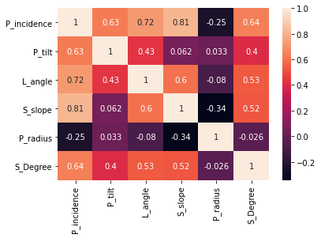

```python
sns.heatmap(df.corr(),annot = True)
```

B. SHaring Insights on correlation

S_slope has high positive correlation with P_incidence of 0.81  
L_angle has good positive correlation with P_incidence of 0.72  
P_radius has a very low correllation with P_tilt of 0.033

C. visualizing a pairplot with 3 classes distinguished by colors

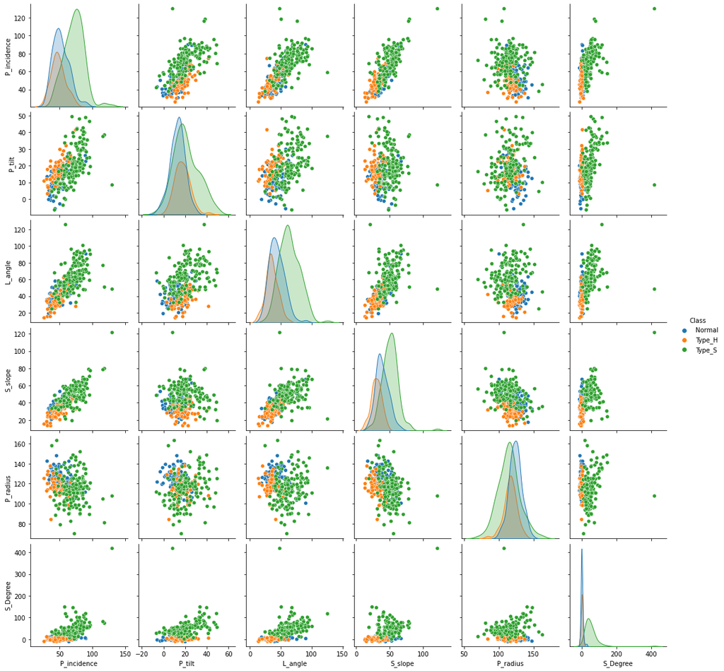

```python
sns.pairplot(data = df, hue = 'Class')
```

D. visualising a jointplot

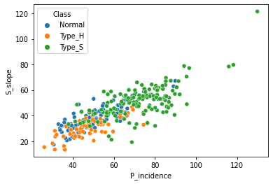

```python
sns.scatterplot(data = df,x = 'P_incidence',y = 'S_slope',hue = 'Class')
```

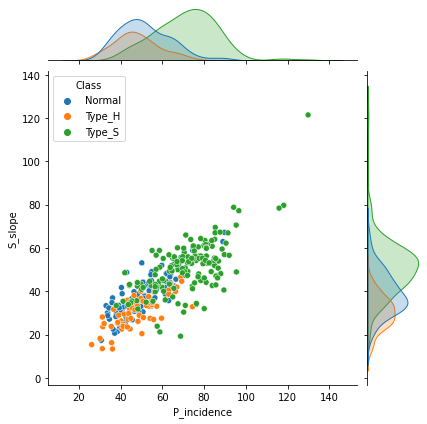

```python
sns.jointplot(data = df,x = 'P_incidence',y = 'S_slope',hue = 'Class')
```

From the above plot , it looks like S_Slope and P_incidence are higly correlated to each other with tyoe_H and type_s classes with seperable boundaries  
We also saw with correllation values

E. Visualizing a boxplot to check distribution

```python
df.columns
```

```
Index(['P_incidence', 'P_tilt', 'L_angle', 'S_slope', 'P_radius', 'S_Degree',
       'Class'],
      dtype='object')
```

```python
df.describe()
```

|  | P_incidence | P_tilt | L_angle | S_slope | P_radius | S_Degree |
| --- | --- | --- | --- | --- | --- | --- |
| count | 310.000000 | 310.000000 | 310.000000 | 310.000000 | 310.000000 | 310.000000 |
| mean | 60.496653 | 17.542822 | 51.930930 | 42.953831 | 117.920655 | 26.296694 |
| std | 17.236520 | 10.008330 | 18.554064 | 13.423102 | 13.317377 | 37.559027 |
| min | 26.147921 | -6.554948 | 14.000000 | 13.366931 | 70.082575 | -11.058179 |
| 25% | 46.430294 | 10.667069 | 37.000000 | 33.347122 | 110.709196 | 1.603727 |
| 50% | 58.691038 | 16.357689 | 49.562398 | 42.404912 | 118.268178 | 11.767934 |
| 75% | 72.877696 | 22.120395 | 63.000000 | 52.695888 | 125.467674 | 41.287352 |
| max | 129.834041 | 49.431864 | 125.742385 | 121.429566 | 163.071041 | 418.543082 |

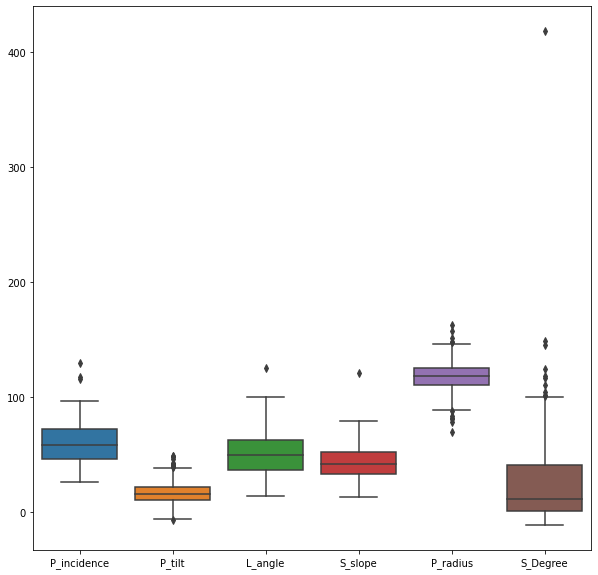

```python
plt.figure(figsize=(10,10))
sns.boxplot(data = df)
```

From above plot  
P_incidence and L_angle has similar distribution,their mean values are close to each other  
L_angle and S_slope have very low outliers

## 4. Model Building

```python
from sklearn.metrics import classification_report,confusion_matrix,plot_confusion_matrix,accuracy_score
from sklearn.model_selection import train_test_split
from sklearn.neighbors import KNeighborsClassifier
from sklearn.preprocessing import StandardScaler
```

```python
df.tail()
```

|  | P_incidence | P_tilt | L_angle | S_slope | P_radius | S_Degree | Class |
| --- | --- | --- | --- | --- | --- | --- | --- |
| 145 | 80.111572 | 33.942432 | 85.101608 | 46.169139 | 125.593624 | 100.292107 | Type_S |
| 146 | 95.480229 | 46.550053 | 59.000000 | 48.930176 | 96.683903 | 77.283072 | Type_S |
| 147 | 74.094731 | 18.823727 | 76.032156 | 55.271004 | 128.405731 | 73.388216 | Type_S |
| 148 | 87.679087 | 20.365613 | 93.822416 | 67.313473 | 120.944829 | 76.730629 | Type_S |
| 149 | 48.259920 | 16.417462 | 36.329137 | 31.842457 | 94.882336 | 28.343799 | Type_S |

```python
df = df.sample(frac=1)
```

```python
df.head()
```

|  | P_incidence | P_tilt | L_angle | S_slope | P_radius | S_Degree | Class |
| --- | --- | --- | --- | --- | --- | --- | --- |
| 15 | 44.318907 | 12.537992 | 36.098763 | 31.780915 | 124.115836 | 5.415825 | Type_H |
| 63 | 35.877571 | 1.112374 | 43.457257 | 34.765197 | 126.923906 | -1.632238 | Normal |
| 17 | 61.540599 | 19.676957 | 52.892229 | 41.863642 | 118.686268 | 4.815031 | Normal |
| 26 | 59.785265 | 17.879323 | 59.206461 | 41.905942 | 119.319111 | 22.123869 | Type_S |
| 46 | 65.013773 | 9.838262 | 57.735837 | 55.175511 | 94.738525 | 49.696955 | Type_S |

A. Split data into X and Y

```python
X = df.drop('Class',axis =1)
y = df['Class']
```

B. Split data into train and test with 80:20 proportion

```python
X_train, X_test, y_train, y_test = train_test_split(X, y, test_size=0.2, random_state=101)
```

```python
X_train.head()
```

|  | P_incidence | P_tilt | L_angle | S_slope | P_radius | S_Degree |
| --- | --- | --- | --- | --- | --- | --- |
| 145 | 80.111572 | 33.942432 | 85.101608 | 46.169139 | 125.593624 | 100.292107 |
| 10 | 44.489275 | 21.786433 | 31.474154 | 22.702842 | 113.778494 | -0.284129 |
| 12 | 48.915551 | 19.964556 | 40.263794 | 28.950995 | 119.321358 | 8.028895 |
| 5 | 40.250200 | 13.921907 | 25.124950 | 26.328293 | 130.327871 | 2.230652 |
| 121 | 64.624008 | 15.225303 | 67.632167 | 49.398705 | 90.298468 | 31.326411 |

```python
X_test.shape
```

```
(62, 6)
```

```python
scaler = StandardScaler()
```

```python
scaled_X_train = scaler.fit_transform(X_train)
```

```python
scaled_X_test = scaler.transform(X_test)
```

C. Train a Supervised Learning Classification base model using KNN classifier

```python
model = KNeighborsClassifier(n_neighbors=1)
```

```python
# model.fit(X_train,y_train)
model.fit(scaled_X_train,y_train)
```

```
KNeighborsClassifier(n_neighbors=1)
```

```python
y_pred = model.predict(scaled_X_test)
# y_pred = model.predict(X_test)
```

```python
# confusion_matrix(y_test,y_pred)
```

D. Print all the possible performance metrics for both train and test data.

```python
print(classification_report(y_test,y_pred))
```

```
              precision    recall  f1-score   support

      Normal       0.77      0.89      0.83        19
      Type_H       0.91      0.77      0.83        13
      Type_S       0.86      0.83      0.85        30

    accuracy                           0.84        62
   macro avg       0.85      0.83      0.84        62
weighted avg       0.84      0.84      0.84        62
```

```python
print(classification_report(y_test,y_pred))
```

```
              precision    recall  f1-score   support

      Normal       0.77      0.89      0.83        19
      Type_H       0.91      0.77      0.83        13
      Type_S       0.86      0.83      0.85        30

    accuracy                           0.84        62
   macro avg       0.85      0.83      0.84        62
weighted avg       0.84      0.84      0.84        62
```

```python
accuracy_score(y_test,y_pred)
```

```
0.8387096774193549
```

```python
df.head(1)
```

|  | P_incidence | P_tilt | L_angle | S_slope | P_radius | S_Degree | Class |
| --- | --- | --- | --- | --- | --- | --- | --- |
| 15 | 44.318907 | 12.537992 | 36.098763 | 31.780915 | 124.115836 | 5.415825 | Type_H |

```python
df['Class'].value_counts(normalize=True)
```

```
Type_S    0.483871
Normal    0.322581
Type_H    0.193548
Name: Class, dtype: float64
```

## 5. Performance Improvement

A. Experiment with various parameters to improve performance of the base model.

```python
test_error_rates = []

for k in range(1,30):
    model = KNeighborsClassifier(n_neighbors=k)
    model.fit(scaled_X_train,y_train)
    # model.fit(X_train,y_train)


    y_pred_test = model.predict(scaled_X_test)
    # y_pred_test = model.predict(X_test)


    test_error = 1 - accuracy_score(y_test,y_pred_test)
    test_error_rates.append(test_error)
```

B. Clearly showcase improvement in performance achieved

```python
test_error_rates
```

```
[0.16129032258064513,
 0.20967741935483875,
 0.19354838709677424,
 0.22580645161290325,
 0.22580645161290325,
 0.24193548387096775,
 0.20967741935483875,
 0.22580645161290325,
 0.19354838709677424,
 0.16129032258064513,
 0.19354838709677424,
 0.16129032258064513,
 0.17741935483870963,
 0.16129032258064513,
 0.14516129032258063,
 0.16129032258064513,
 0.14516129032258063,
 0.16129032258064513,
 0.11290322580645162,
 0.12903225806451613,
 0.12903225806451613,
 0.12903225806451613,
 0.12903225806451613,
 0.12903225806451613,
 0.14516129032258063,
 0.14516129032258063,
 0.16129032258064513,
 0.16129032258064513,
 0.16129032258064513]
```

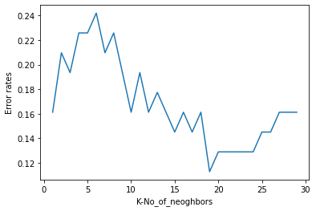

```python
plt.plot(range(1,30),test_error_rates)
plt.ylabel('Error rates')
plt.xlabel('K-No_of_neoghbors')
plt.show()
```

From above plot. it looks like model with for k,which has lowest error rate can be chosen for best model

C. Clearly state which parameters contributed most to improve model performance. [

As we run the model on different k values to check error rates,  
Clearly K parameter that is the number of Neighbors contributed to improvement of model performance as it brings down the error rate in accuracy

# Part B

PROJECT OBJECTIVE: Build a Machine Learning model to perform focused marketing by predicting the potential customers who will convert using the historical dataset

## Data Understanding and Preparation

A. Reading both the datasets

```python
df_1 = pd.read_csv('Part2+-+Data1.csv')
df_2 = pd.read_csv('Part2+-Data2.csv')
```

```python
df_1.head()
```

|  | ID | Age | CustomerSince | HighestSpend | ZipCode | HiddenScore | MonthlyAverageSpend | Level |
| --- | --- | --- | --- | --- | --- | --- | --- | --- |
| 0 | 1 | 25 | 1 | 49 | 91107 | 4 | 1.6 | 1 |
| 1 | 2 | 45 | 19 | 34 | 90089 | 3 | 1.5 | 1 |
| 2 | 3 | 39 | 15 | 11 | 94720 | 1 | 1.0 | 1 |
| 3 | 4 | 35 | 9 | 100 | 94112 | 1 | 2.7 | 2 |
| 4 | 5 | 35 | 8 | 45 | 91330 | 4 | 1.0 | 2 |

```python
df_2.head()
```

|  | ID | Mortgage | Security | FixedDepositAccount | InternetBanking | CreditCard | LoanOnCard |
| --- | --- | --- | --- | --- | --- | --- | --- |
| 0 | 1 | 0 | 1 | 0 | 0 | 0 | NaN |
| 1 | 2 | 0 | 1 | 0 | 0 | 0 | NaN |
| 2 | 3 | 0 | 0 | 0 | 0 | 0 | NaN |
| 3 | 4 | 0 | 0 | 0 | 0 | 0 | NaN |
| 4 | 5 | 0 | 0 | 0 | 0 | 1 | NaN |

```python
df_1.info()
```

```
<class 'pandas.core.frame.DataFrame'>
RangeIndex: 5000 entries, 0 to 4999
Data columns (total 8 columns):
 #   Column               Non-Null Count  Dtype
---  ------               --------------  -----
 0   ID                   5000 non-null   int64
 1   Age                  5000 non-null   int64
 2   CustomerSince        5000 non-null   int64
 3   HighestSpend         5000 non-null   int64
 4   ZipCode              5000 non-null   int64
 5   HiddenScore          5000 non-null   int64
 6   MonthlyAverageSpend  5000 non-null   float64
 7   Level                5000 non-null   int64
dtypes: float64(1), int64(7)
memory usage: 312.6 KB
```

```python
df_2.info()
print()
```

```
<class 'pandas.core.frame.DataFrame'>
RangeIndex: 5000 entries, 0 to 4999
Data columns (total 7 columns):
 #   Column               Non-Null Count  Dtype
---  ------               --------------  -----
 0   ID                   5000 non-null   int64
 1   Mortgage             5000 non-null   int64
 2   Security             5000 non-null   int64
 3   FixedDepositAccount  5000 non-null   int64
 4   InternetBanking      5000 non-null   int64
 5   CreditCard           5000 non-null   int64
 6   LoanOnCard           4980 non-null   float64
dtypes: float64(1), int64(6)
memory usage: 273.6 KB
```

B. shape and column names of both datasets

```python
print("Shape of 1st dataFrame : {}".format(df_1.shape))
print("Columns of 1st dataFrame : {}".format(list(df_1.columns)))
print("\ndatatype of 1st dataFrame :\n {}".format(df_1.dtypes))
```

```
Shape of 1st dataFrame : (5000, 8)
Columns of 1st dataFrame : ['ID', 'Age', 'CustomerSince', 'HighestSpend', 'ZipCode', 'HiddenScore', 'MonthlyAverageSpend', 'Level']

datatype of 1st dataFrame :
 ID                       int64
Age                      int64
CustomerSince            int64
HighestSpend             int64
ZipCode                  int64
HiddenScore              int64
MonthlyAverageSpend    float64
Level                    int64
dtype: object
```

```python
print("Shape of 2nd dataFrame : {}".format(df_2.shape))
print("Columns of 2nd dataFrame : {}".format(list(df_2.columns)))
print("\ndatatype of 2nd dataFrame :\n {}".format(df_2.dtypes))
print()
```

```
Shape of 2nd dataFrame : (5000, 7)
Columns of 2nd dataFrame : ['ID', 'Mortgage', 'Security', 'FixedDepositAccount', 'InternetBanking', 'CreditCard', 'LoanOnCard']

datatype of 2nd dataFrame :
 ID                       int64
Mortgage                 int64
Security                 int64
FixedDepositAccount      int64
InternetBanking          int64
CreditCard               int64
LoanOnCard             float64
dtype: object
```

C. Merging both dataframes to form single dataframe

```python
df = pd.merge(df_1,df_2,on = 'ID',how = 'inner')
```

```python
df.shape
```

```
(5000, 14)
```

```python
df.columns
```

```
Index(['ID', 'Age', 'CustomerSince', 'HighestSpend', 'ZipCode', 'HiddenScore',
       'MonthlyAverageSpend', 'Level', 'Mortgage', 'Security',
       'FixedDepositAccount', 'InternetBanking', 'CreditCard', 'LoanOnCard'],
      dtype='object')
```

```python
df.info()
print()
```

```
<class 'pandas.core.frame.DataFrame'>
Int64Index: 5000 entries, 0 to 4999
Data columns (total 14 columns):
 #   Column               Non-Null Count  Dtype
---  ------               --------------  -----
 0   ID                   5000 non-null   int64
 1   Age                  5000 non-null   int64
 2   CustomerSince        5000 non-null   int64
 3   HighestSpend         5000 non-null   int64
 4   ZipCode              5000 non-null   int64
 5   HiddenScore          5000 non-null   int64
 6   MonthlyAverageSpend  5000 non-null   float64
 7   Level                5000 non-null   int64
 8   Mortgage             5000 non-null   int64
 9   Security             5000 non-null   int64
 10  FixedDepositAccount  5000 non-null   int64
 11  InternetBanking      5000 non-null   int64
 12  CreditCard           5000 non-null   int64
 13  LoanOnCard           4980 non-null   float64
dtypes: float64(2), int64(12)
memory usage: 585.9 KB
```

D. Changing datatype of below features

```python
df['CreditCard'] = df['CreditCard'].astype('str')
df['InternetBanking']= df['InternetBanking'].astype('str')
df['FixedDepositAccount'] = df['FixedDepositAccount'].astype('str')
df['Security'] = df['Security'].astype('str')
df['Level'] = df['Level'].astype('str')
df['HiddenScore'] = df['HiddenScore'].astype('str')
```

```python
df.info()
# d = df.copy()
print()
```

```
<class 'pandas.core.frame.DataFrame'>
Int64Index: 5000 entries, 0 to 4999
Data columns (total 14 columns):
 #   Column               Non-Null Count  Dtype
---  ------               --------------  -----
 0   ID                   5000 non-null   int64
 1   Age                  5000 non-null   int64
 2   CustomerSince        5000 non-null   int64
 3   HighestSpend         5000 non-null   int64
 4   ZipCode              5000 non-null   int64
 5   HiddenScore          5000 non-null   object
 6   MonthlyAverageSpend  5000 non-null   float64
 7   Level                5000 non-null   object
 8   Mortgage             5000 non-null   int64
 9   Security             5000 non-null   object
 10  FixedDepositAccount  5000 non-null   object
 11  InternetBanking      5000 non-null   object
 12  CreditCard           5000 non-null   object
 13  LoanOnCard           4980 non-null   float64
dtypes: float64(2), int64(6), object(6)
memory usage: 585.9+ KB
```

## 2. Data Exploration and Analysis

A. Visualizing distribution of target variable

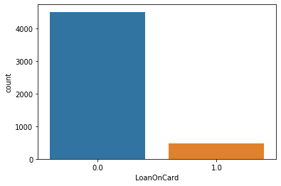

```python
sns.countplot(data = df,x = 'LoanOnCard')
plt.show()
```

```python
df['LoanOnCard'].value_counts(normalize=False)
```

```
0.0    4500
1.0     480
Name: LoanOnCard, dtype: int64
```

```python
df['LoanOnCard'].value_counts(normalize=True)*100
```

```
0.0    90.361446
1.0     9.638554
Name: LoanOnCard, dtype: float64
```

As we can see from the above distribution, LoanOnCard has an imbalanced class distribution  
LoanOnCard - has 90% of its values as Class 0  
LoanOnCard - has 10% of its values as Class 1

B. Checking the null values

```python
df.isna().sum()
```

```
ID                      0
Age                     0
CustomerSince           0
HighestSpend            0
ZipCode                 0
HiddenScore             0
MonthlyAverageSpend     0
Level                   0
Mortgage                0
Security                0
FixedDepositAccount     0
InternetBanking         0
CreditCard              0
LoanOnCard             20
dtype: int64
```

LoanOnCard has 20 of its total values as null

```python
print('percentage of missing values for LoanOnCard : {} %'.format(df.isna().sum()[-1]/df.shape[0]*100))
```

```
percentage of missing values for LoanOnCard : 0.4 %
```

```python
print('As the percentage of null values is very low, We can drop those rows and proceed')
```

```
As the percentage of null values is very low, We can drop those rows and proceed
```

```python
df.dtypes
```

```
ID                       int64
Age                      int64
CustomerSince            int64
HighestSpend             int64
ZipCode                  int64
HiddenScore             object
MonthlyAverageSpend    float64
Level                   object
Mortgage                 int64
Security                object
FixedDepositAccount     object
InternetBanking         object
CreditCard              object
LoanOnCard             float64
dtype: object
```

C. checking for unexpected values in a feature and impute if required

Below are the unique values present in Categorical columns

```python
for i in df.columns:
    if df[i].dtype == 'object':
        print(i)
        print(df[i].unique())
        print()
```

```
HiddenScore
['4' '3' '1' '2']

Level
['1' '2' '3']

Security
['1' '0']

FixedDepositAccount
['0' '1']

InternetBanking
['0' '1']

CreditCard
['0' '1']
```

All values in above categorical features are correct values

```python
df.head()
```

|  | ID | Age | CustomerSince | HighestSpend | ZipCode | HiddenScore | MonthlyAverageSpend | Level | Mortgage | Security | FixedDepositAccount | InternetBanking | CreditCard | LoanOnCard |
| --- | --- | --- | --- | --- | --- | --- | --- | --- | --- | --- | --- | --- | --- | --- |
| 0 | 1 | 25 | 1 | 49 | 91107 | 4 | 1.6 | 1 | 0 | 1 | 0 | 0 | 0 | NaN |
| 1 | 2 | 45 | 19 | 34 | 90089 | 3 | 1.5 | 1 | 0 | 1 | 0 | 0 | 0 | NaN |
| 2 | 3 | 39 | 15 | 11 | 94720 | 1 | 1.0 | 1 | 0 | 0 | 0 | 0 | 0 | NaN |
| 3 | 4 | 35 | 9 | 100 | 94112 | 1 | 2.7 | 2 | 0 | 0 | 0 | 0 | 0 | NaN |
| 4 | 5 | 35 | 8 | 45 | 91330 | 4 | 1.0 | 2 | 0 | 0 | 0 | 0 | 1 | NaN |

## 3.Data Preparation and model Building

Dropping the null values as rows

```python
df.info()
```

```
<class 'pandas.core.frame.DataFrame'>
Int64Index: 5000 entries, 0 to 4999
Data columns (total 14 columns):
 #   Column               Non-Null Count  Dtype
---  ------               --------------  -----
 0   ID                   5000 non-null   int64
 1   Age                  5000 non-null   int64
 2   CustomerSince        5000 non-null   int64
 3   HighestSpend         5000 non-null   int64
 4   ZipCode              5000 non-null   int64
 5   HiddenScore          5000 non-null   object
 6   MonthlyAverageSpend  5000 non-null   float64
 7   Level                5000 non-null   object
 8   Mortgage             5000 non-null   int64
 9   Security             5000 non-null   object
 10  FixedDepositAccount  5000 non-null   object
 11  InternetBanking      5000 non-null   object
 12  CreditCard           5000 non-null   object
 13  LoanOnCard           4980 non-null   float64
dtypes: float64(2), int64(6), object(6)
memory usage: 715.0+ KB
```

```python
df.shape
```

```
(5000, 14)
```

```python
df.dropna(inplace = True)
```

```python
df.shape
```

```
(4980, 14)
```

```python
df.drop(columns = ['ID','ZipCode'],axis = 1,inplace = True)
```

```python
df.shape
d = df.copy()
```

```python
from sklearn.linear_model import LogisticRegression
from sklearn.model_selection import train_test_split
from sklearn.metrics import classification_report,confusion_matrix
```

A. Spliting data in X and Y

```python
X = df.drop(columns = ['LoanOnCard'],axis = 1)
y = df['LoanOnCard']
print()
```

B. Spliting the above data into train and tests

```python
X_train, X_test, y_train, y_test = train_test_split(X,y,test_size=0.25,random_state=1234)
```

```python
print("Number transactions X_train dataset: ", X_train.shape)
print("Number transactions y_train dataset: ", y_train.shape)
print("Number transactions X_test dataset: ", X_test.shape)
print("Number transactions y_test dataset: ", y_test.shape)
```

```
Number transactions X_train dataset:  (3735, 11)
Number transactions y_train dataset:  (3735,)
Number transactions X_test dataset:  (1245, 11)
Number transactions y_test dataset:  (1245,)
```

C. Training a Logistic regression as a base model

```python
log_cls = LogisticRegression()
```

```python
log_cls.fit(X_train,y_train)
```

```
LogisticRegression()
```

```python
y_pred = log_cls.predict(X_test)
```

D. Evaluation metrics for the model and sharing insights

```python
print(classification_report(y_test,y_pred))
```

```
              precision    recall  f1-score   support

         0.0       0.96      0.99      0.97      1138
         1.0       0.82      0.56      0.67       107

    accuracy                           0.95      1245
   macro avg       0.89      0.77      0.82      1245
weighted avg       0.95      0.95      0.95      1245
```

The accuracy comes out to be 95%  
The recall of the minority class is very less. It proves that the model is more biased towards majority class.  
This is due to the data has unbalanced classes as we explored earlier  
So data should be balanced with 50-50 balanced classes

```python
df.LoanOnCard.value_counts()
```

```
0.0    4500
1.0     480
Name: LoanOnCard, dtype: int64
```

E . balancing the data

```python
# pip install imblearn
```

```python
from imblearn.over_sampling import SMOTE
# sm = SMOTE(random_state = 2)
# X_train_res, y_train_res = sm.fit_sample(X_train, y_train.ravel())
```

```python
print("Before OverSampling, counts of label '1': {}".format(sum(y_train == 1)))
print("Before OverSampling, counts of label '0': {} \n".format(sum(y_train == 0)))

# import SMOTE module from imblearn library
# pip install imblearn (if you don't have imblearn in your system)
from imblearn.over_sampling import SMOTE
sm = SMOTE(random_state = 2)
X_train_res, y_train_res = sm.fit_resample(X_train, y_train.ravel())

print('After OverSampling, the shape of train_X: {}'.format(X_train_res.shape))
print('After OverSampling, the shape of train_y: {} \n'.format(y_train_res.shape))

print("After OverSampling, counts of label '1': {}".format(sum(y_train_res == 1)))
print("After OverSampling, counts of label '0': {}".format(sum(y_train_res == 0)))
```

```
Before OverSampling, counts of label '1': 373
Before OverSampling, counts of label '0': 3362

After OverSampling, the shape of train_X: (6724, 11)
After OverSampling, the shape of train_y: (6724,)

After OverSampling, counts of label '1': 3362
After OverSampling, counts of label '0': 3362
```

F. Training the model on balanced data

```python
lof_model = LogisticRegression()
lof_model.fit(X_train_res, y_train_res.ravel())
predictions = lof_model.predict(X_test)
```

G. Print evaluation metrics and clearly share differences observed.

```python
# print classification report
print(classification_report(y_test, predictions))
```

```
              precision    recall  f1-score   support

         0.0       0.99      0.89      0.94      1138
         1.0       0.44      0.93      0.59       107

    accuracy                           0.89      1245
   macro avg       0.71      0.91      0.76      1245
weighted avg       0.94      0.89      0.91      1245
```

It looks like accuracy is reduced to 89% as compared to previous model but the recall value of minority class has also improved to 93 %. This is a good model compared to the previous one. Recall is great.

## 4. Performance Improvement:

A. Train a base model each for SVM, KNN

```python
X = d.drop(columns = ['LoanOnCard'],axis = 1)
y = d['LoanOnCard']
print()

X_train, X_test, y_train, y_test = train_test_split(X,y,test_size=0.25,random_state=1234)
from imblearn.over_sampling import SMOTE
sm = SMOTE(random_state = 2)
X_train_RE, y_train_RE = sm.fit_resample(X_train, y_train.ravel())
```

```python
scaler = StandardScaler()
```

```python
X_train_RE = scaler.fit_transform(X_train_RE)
X_test = scaler.transform(X_test)
```

```python
from sklearn.neighbors import KNeighborsClassifier
from sklearn.svm import SVC
```

```python
knn_model = KNeighborsClassifier(n_neighbors=1)
knn_model.fit(X_train_RE,y_train_RE)
```

```
KNeighborsClassifier(n_neighbors=1)
```

```python
y_pred_knn = knn_model.predict(X_test)
```

```python
accuracy_score(y_test,y_pred_knn)
# 1 - accuracy_score(y_test,y_pred_knn)
```

```
0.9654618473895582
```

```python
1 - accuracy_score(y_test,y_pred_knn)
```

```
0.0345381526104418
```

```python
print(classification_report(y_test,y_pred_knn))
```

```
              precision    recall  f1-score   support

         0.0       0.98      0.99      0.98      1138
         1.0       0.83      0.76      0.79       107

    accuracy                           0.97      1245
   macro avg       0.90      0.87      0.89      1245
weighted avg       0.96      0.97      0.96      1245
```

```python
svm_model = SVC()
```

```python
svm_model.fit(X_train_RE,y_train_RE)
```

```
SVC()
```

```python
svm_y_pred = svm_model.predict(X_test)
```

```python
print(classification_report(y_test,svm_y_pred))
```

```
              precision    recall  f1-score   support

         0.0       0.99      0.98      0.98      1138
         1.0       0.81      0.84      0.83       107

    accuracy                           0.97      1245
   macro avg       0.90      0.91      0.90      1245
weighted avg       0.97      0.97      0.97      1245
```

It looks as SVM has a greater accuracy and recall as compared to KNN

B. Tune parameters for each of the models

```python
error_test_rate = []

for k in range(1,30):
    knn_model = KNeighborsClassifier(n_neighbors=k)
    knn_model.fit(X_train_RE,y_train_RE)

    knn_multi_pred = knn_model.predict(X_test)
    error = 1 - accuracy_score(y_test,knn_multi_pred)

    error_test_rate.append(error)
```

```python
# plt.plot(range(1,30),error_test_rate)
```

```python
error_test_rate
```

```
[0.0345381526104418,
 0.03534136546184741,
 0.03935742971887546,
 0.03534136546184741,
 0.03614457831325302,
 0.03614457831325302,
 0.03855421686746985,
 0.03694779116465863,
 0.0417670682730924,
 0.03614457831325302,
 0.03855421686746985,
 0.03694779116465863,
 0.04578313253012045,
 0.04417670682730923,
 0.050602409638554224,
 0.04497991967871484,
 0.049799196787148614,
 0.048192771084337394,
 0.052208835341365445,
 0.053815261044176665,
 0.053012048192771055,
 0.051405622489959835,
 0.054618473895582276,
 0.051405622489959835,
 0.05863453815261044,
 0.055421686746988,
 0.05863453815261044,
 0.05622489959839361,
 0.06024096385542166]
```

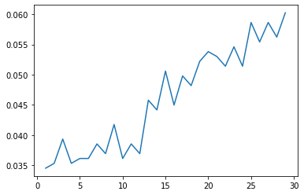

```python
plt.plot(range(1,30),error_test_rate)
```

```python
from sklearn.model_selection import GridSearchCV
```

```python
svm = SVC()
```

```python
param_grid = {'C':[0.01,0.1,1],'kernel':['linear','rbf']}
```

```python
grid = GridSearchCV(svm,param_grid)
```

```python
grid.fit(X_train_RE, y_train_RE)
```

```
GridSearchCV(estimator=SVC(),
             param_grid={'C': [0.01, 0.1, 1], 'kernel': ['linear', 'rbf']})
```

```python
grid.best_params_
```

```
{'C': 1, 'kernel': 'rbf'}
```

```python
grid.best_estimator_
```

```
SVC(C=1)
```

C. Print evaluation metrics for final model.

```python
grid_preds = grid.predict(X_test)
```

```python
print(classification_report(y_test,grid_preds))
```

```
              precision    recall  f1-score   support

         0.0       0.99      0.98      0.98      1138
         1.0       0.81      0.84      0.83       107

    accuracy                           0.97      1245
   macro avg       0.90      0.91      0.90      1245
weighted avg       0.97      0.97      0.97      1245
```

D. improvement achieved from base model to final model.

From above classification report  
As we move from base model to improved model: svm comes to be the best model with good classification metrics that the model with {'C': 1, 'kernel': 'rbf'} derived by hyperparameter tuning